# Regression 4: Review

March 30 2022

```r
library(tidyverse)
library(tidymodels)
```

# Bulletin

- Friday
  - peer reviews due
  - exam 02 released

# Today

Today we review and practice linear modeling concepts with the Palmer penguins data.

```r
data(penguins)
```

Use `?penguins` or [click here](https://github.com/allisonhorst/palmerpenguins) for more info about the dataset.

# Main vs interaction effects

$y$: body mass (g)

$x_1$: bill length

$x_2$: island Dream

$x_3$: island Torgersen

$$\hat{y} = \hat{\beta_0} + \hat{\beta_1} x_1 + \hat{\beta_2} x_2 + \hat{\beta_3} x_3$$

Bill length only impacts body mass via the term $\beta_1 x_1$. $x_2$ and $x_3$ can be thought of as turning on or off a constant.

## Main

| term | estimate | std.error | statistic | p.value |
| --- | --- | --- | --- | --- |
| (Intercept) | 1225.79107 | 243.180592 | 5.040662 | 7.576684e-07 |
| bill_length_mm | 77.11933 | 5.306978 | 14.531683 | 1.656434e-37 |
| islandDream | -919.07448 | 58.622251 | -15.677912 | 5.151598e-42 |
| islandTorgersen | -523.29201 | 85.549545 | -6.116830 | 2.638570e-09 |

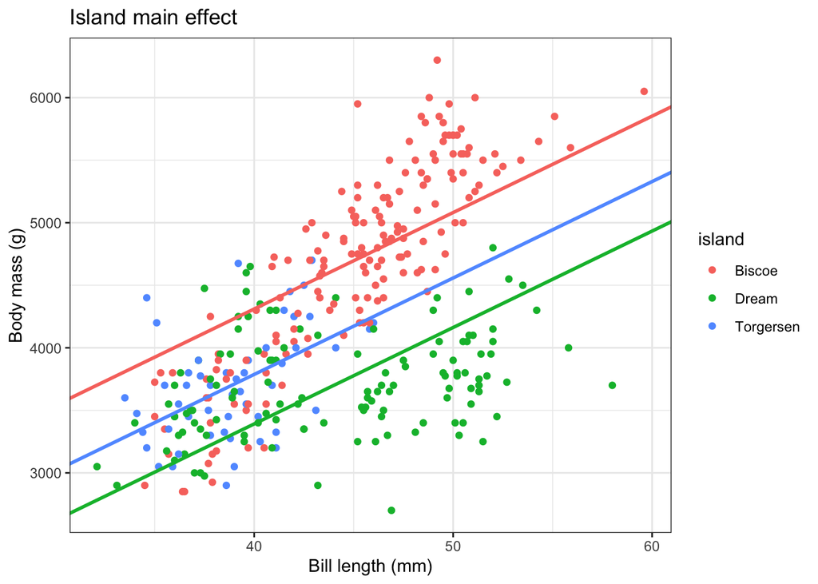

## Interaction

$$\hat{y} = \hat{\beta_0} + \hat{\beta_1} x_1 + \hat{\beta_2} x_2 + \hat{\beta_3} x_3 + \hat{\beta_4} x_1 x_2 + \hat{\beta_5} x_1 x_3$$

What’s different? The interaction terms ($\beta_4 x_1 x_2$ and $\beta_5 x_1 x_3$).

| term | estimate | std.error | statistic | p.value |
| --- | --- | --- | --- | --- |
| (Intercept) | -1726.02014 | 292.078750 | -5.909434 | 8.425393e-09 |
| bill_length_mm | 142.34194 | 6.418333 | 22.177401 | 9.138892e-68 |
| islandDream | 4478.69269 | 395.307334 | 11.329647 | 2.030517e-25 |
| islandTorgersen | 2870.56340 | 777.685075 | 3.691164 | 2.603717e-04 |
| bill_length_mm:islandDream | -120.60139 | 8.770689 | -13.750505 | 1.930223e-34 |
| bill_length_mm:islandTorgersen | -76.57134 | 19.534154 | -3.919870 | 1.073890e-04 |

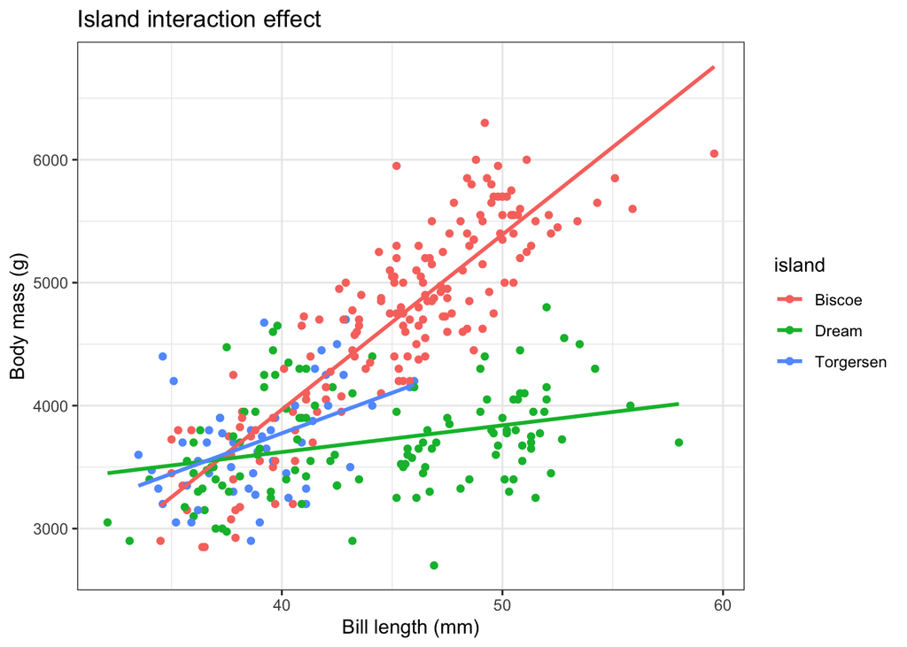

Interpreting interactions can be difficult, especially without writing things down. To make it easier, we will compare the implied linear models:

Plug in 0 for `islandDream` ($x_2$) and 0 for `islandTorgersen` ($x_3$) to get the linear model for `islandBiscoe` penguins

Plug in 1 for `islandDream` ($x_2$) and 0 for `islandTorgersen` ($x_3$) to get the linear model for `islandDream` penguins

Plug in 0 for `islandDream` ($x_2$) and 1 for `islandTorgersen` ($x_3$) to get the linear model for `islandTorgersen` penguins

- Biscoe fitted model:

$$\hat{y} = -1726.0+ 142.3 x_1$$

- Dream fitted model:

$$\hat{y} = -1726.0 + 142.3 x_1 + 4478.7 -120.6 x_1$$

Combine terms:

$$\hat{y} = 2752.7 + 21.7 x_1$$

## Exercise 1

Write out the fitted model for Torgersen island below.

- Torgersen model:
  $$\hat{y} = [\text{write here}]$$

# Interpreting

Now we can interpret the interaction model by comparing bill length slopes between islands.

- For a unit increase in bill length of a penguin from the island Dream, how much do we expect the body mass to increase?

## Exercise 2

- You measured the bill length of a penguin from island Biscoe and a penguin from island Torgersen a year ago. You re-measure them today and find the bill length of each one grew by exactly 2 mm. How much mass do you expect each penguin to have gained?

## Exercise 3

Are the intercepts meaningful?

# Practice

## Exercise 4

Is the relationship between Body mass (g) and Bill depth (mm) positive or negative? Create a convincing argument from the data.

## Exercise 5

Let’s build a linear model of body mass using bill depth and one other predictor of your choosing (hint: see previous exercise!)

- Write out a linear model with both predictors and fit the model.
- Fit the linear model
- Are any of the predictors insignificant at the $\alpha = 0.05$ level? If so, state the null and alternative hypothesis, p-value and conclusion in context.
- Do you prefer this model to the interaction effects model from above? Why?